# Principal Component Analysis

ChatGPT 4o

2025-01-21

## 1 起源

主成分分析（Principal Component Analysis, PCA）是一种数据降维技术，最早由卡尔·皮尔逊（Karl Pearson）在1901年提出。PCA最初用于简化数据集并揭示变量之间的结构性关联。之后由哈罗德·霍特林（Harold Hotelling）在1933年进一步推广，成为统计学、机器学习和信号处理中的重要工具。它广泛应用于需要降低数据维度而不显著损失信息的各种领域。

## 2 原理

PCA的核心思想是通过线性变换将原始数据集中的多个变量组合为少数几个主成分（Principal Components），这些主成分是彼此不相关的，并且保留了数据中最大的方差信息。具体来说，PCA通过以下步骤实现降维：

1. **标准化数据**：如果不同变量的量纲不一致，先对数据进行标准化，使各变量均值为0，方差为1。
2. **计算协方差矩阵**：用于衡量变量之间的相关性。
3. **计算特征值和特征向量**：对协方差矩阵进行特征值分解，得到特征值和特征向量。
4. **选择主成分**：根据特征值的大小选择主成分，通常选择前几个特征值较大的主成分，以保留大部分数据方差。
5. **转换数据**：将原始数据投影到主成分构成的新空间中，实现降维。

PCA旨在最大化新特征（主成分）的方差，使得前几个主成分能够解释数据中尽可能多的变异性。

## 3 适用范围

PCA适用于以下情况：

- **高维数据集**：数据维度较高，且变量之间存在较强的相关性，适合使用PCA进行降维，以便于数据的可视化和分析。
- **数据标准化**：PCA适用于变量取值范围差异较大的情况，但在进行PCA之前需要对数据进行标准化或归一化处理。
- **需要减少特征数量**：用于简化模型，减少计算复杂度，并在降低维度的同时尽量保留数据的主要信息。

## 4 应用情境

PCA在许多实际应用中被广泛使用，例如：

- **图像处理**：用于降维和压缩，提取图像的主要特征以便于分类和识别。
- **基因表达数据分析**：在生物信息学中用于分析基因表达数据，减少维度并找出主导的基因特征。
- **金融数据分析**：用于简化金融数据，识别影响股票价格的主要因素。
- **噪声去除**：在信号处理领域，通过降维去除噪声，使得信号更加清晰。

## 5 优缺点

### 优点

- **降维效果好**：PCA能够有效减少数据维度，去除冗余信息，并保留数据的主要特征。
- **降低计算复杂度**：降维后的数据更小，便于进一步的分析和处理，减少计算时间和资源消耗。
- **简化数据可视化**：将高维数据映射到2D或3D空间，有助于数据的可视化和理解。

### 缺点

- **主成分难以解释**：PCA将原始特征转换为线性组合，主成分的物理意义通常不易解释。
- **对线性假设的依赖**：PCA基于线性变换，无法处理变量之间的非线性关系。
- **对异常值敏感**：PCA对异常值敏感，异常值可能对主成分的方向产生较大影响。

## 6 在R中的实现及结果解释

在R中，可以使用`prcomp()`函数实现PCA分析。以下是一个实现示例：

```r
# 加载必要的包
library(ggplot2)

# 示例数据：鸢尾花数据集
data(iris)

data <- iris[, 1:4]  # 选择数值型变量进行PCA

# 进行PCA分析
pca_result <- prcomp(data, center = TRUE, scale. = TRUE)
pca_result
```

```
## Standard deviations (1, .., p=4):
## [1] 1.7083611 0.9560494 0.3830886 0.1439265
##
## Rotation (n x k) = (4 x 4):
##                     PC1         PC2        PC3        PC4
## Sepal.Length  0.5210659 -0.37741762  0.7195664  0.2612863
## Sepal.Width  -0.2693474 -0.92329566 -0.2443818 -0.1235096
## Petal.Length  0.5804131 -0.02449161 -0.1421264 -0.8014492
## Petal.Width   0.5648565 -0.06694199 -0.6342727  0.5235971
```

```r
# 输出PCA结果
summary(pca_result)
```

```
## Importance of components:
##                           PC1    PC2     PC3     PC4
## Standard deviation     1.7084 0.9560 0.38309 0.14393
## Proportion of Variance 0.7296 0.2285 0.03669 0.00518
## Cumulative Proportion  0.7296 0.9581 0.99482 1.00000
```

```r
str(pca_result)
```

```
## List of 5
##  $ sdev    : num [1:4] 1.708 0.956 0.383 0.144
##  $ rotation: num [1:4, 1:4] 0.521 -0.269 0.58 0.565 -0.377 ...
##   ..- attr(*, "dimnames")=List of 2
##   .. ..$ : chr [1:4] "Sepal.Length" "Sepal.Width" "Petal.Length" "Petal.Width"
##   .. ..$ : chr [1:4] "PC1" "PC2" "PC3" "PC4"
##  $ center  : Named num [1:4] 5.84 3.06 3.76 1.2
##   ..- attr(*, "names")= chr [1:4] "Sepal.Length" "Sepal.Width" "Petal.Length" "Petal.Width"
##  $ scale   : Named num [1:4] 0.828 0.436 1.765 0.762
##   ..- attr(*, "names")= chr [1:4] "Sepal.Length" "Sepal.Width" "Petal.Length" "Petal.Width"
##  $ x       : num [1:150, 1:4] -2.26 -2.07 -2.36 -2.29 -2.38 ...
##   ..- attr(*, "dimnames")=List of 2
##   .. ..$ : NULL
##   .. ..$ : chr [1:4] "PC1" "PC2" "PC3" "PC4"
##  - attr(*, "class")= chr "prcomp"
```

### 结果解释

- **标准差（Standard deviation）**：每个主成分的标准差，表示每个主成分的变异程度。
- **比例方差（Proportion of Variance）**：每个主成分解释的方差占总方差的比例，用于判断每个主成分的重要性。
- **累计比例方差（Cumulative Proportion）**：累积方差比例，表示前几个主成分解释的总方差占比，用于决定需要选择多少个主成分。

例如，如果输出结果显示前两个主成分解释了约95.8%的总方差，那么可以只选择前两个主成分进行后续分析。

### 主成分的选择

在进行PCA分析时，主成分的选择是非常关键的，通常需要选择能够解释大部分方差的主成分。以下是一些常用的方法：

- **累计方差比例**：通过查看累计方差比例，选择前几个主成分，使得累计方差比例达到较高的水平（例如90%或95%），以确保保留数据中的主要信息。
- **碎石图（Scree Plot）**：绘制特征值的碎石图，查看主成分的特征值变化情况。通常选择”肘部点”前的主成分，即特征值急剧下降前的几个主成分。

以下是在R中使用碎石图选择主成分的示例：

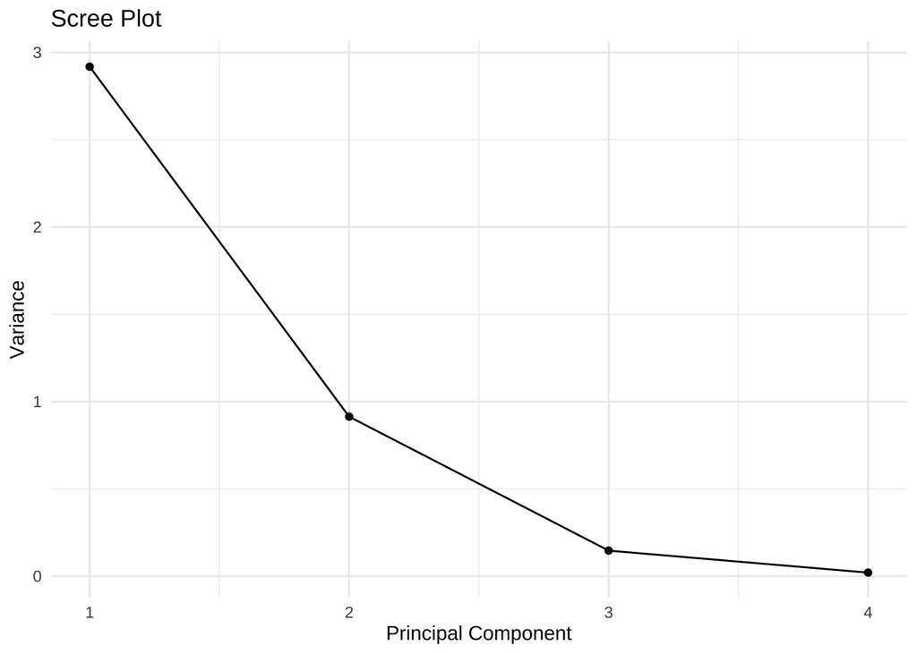

```r
# 绘制碎石图
scree_plot <- data.frame(Principal_Component = 1:length(pca_result$sdev),
                         Variance = pca_result$sdev^2)

ggplot(scree_plot, aes(x = Principal_Component, y = Variance)) +
  geom_line() +
  geom_point() +
  labs(title = "Scree Plot", x = "Principal Component", y = "Variance") +
  theme_minimal()
```

### 旋转方法

在PCA中，主成分的线性组合可能难以解释。通过旋转，可以使得主成分更具解释性。常用的旋转方法包括：

- **正交旋转（Orthogonal Rotation）**：如Varimax旋转，保持主成分之间的正交性，同时使得每个主成分更加稀疏，以便于解释。
- **斜交旋转（Oblique Rotation）**：允许主成分之间相关性，常用于当主成分之间不完全独立的情况下，使得模型更加贴合数据。

在R中，可以使用`psych`包中的`principal()`函数来实现旋转：

```r
# 加载psych包
library(psych)
# 进行PCA分析并应用Varimax旋转
pca_rotated <- principal(data, nfactors = 2, rotate = "varimax", scores = TRUE)
print(pca_rotated)
```

```
## Principal Components Analysis
## Call: principal(r = data, nfactors = 2, rotate = "varimax", scores = TRUE)
## Standardized loadings (pattern matrix) based upon correlation matrix
##                RC1   RC2   h2     u2 com
## Sepal.Length  0.96  0.05 0.92 0.0774 1.0
## Sepal.Width  -0.14  0.98 0.99 0.0091 1.0
## Petal.Length  0.94 -0.30 0.98 0.0163 1.2
## Petal.Width   0.93 -0.26 0.94 0.0647 1.2
##
##                        RC1  RC2
## SS loadings           2.70 1.13
## Proportion Var        0.68 0.28
## Cumulative Var        0.68 0.96
## Proportion Explained  0.71 0.29
## Cumulative Proportion 0.71 1.00
##
## Mean item complexity =  1.1
## Test of the hypothesis that 2 components are sufficient.
##
## The root mean square of the residuals (RMSR) is  0.03
##  with the empirical chi square  1.72  with prob <  NA
##
## Fit based upon off diagonal values = 1
```

通过旋转，主成分的解释力将更加集中在较少的变量上，使得每个主成分的物理意义更加清晰易懂。

### 结果的可视化

可以使用`ggplot2`包对PCA结果进行可视化，以展示数据在前两个主成分上的分布。

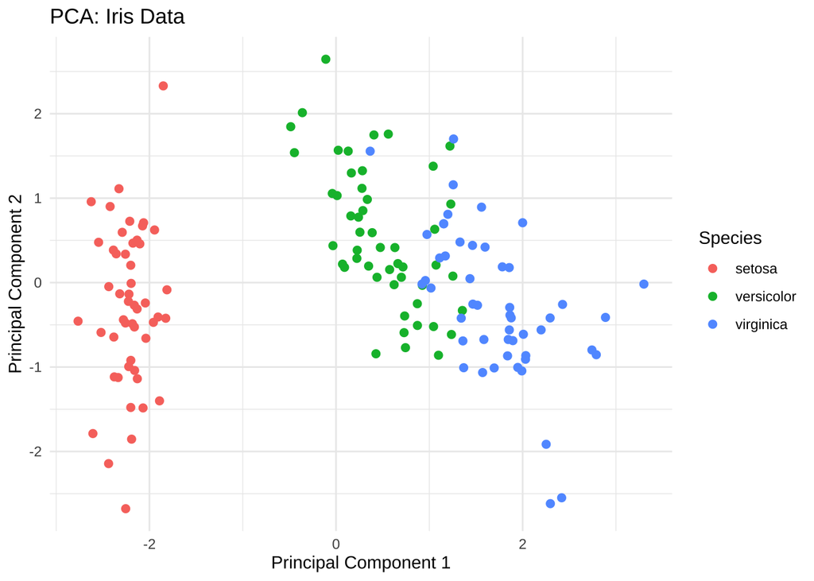

```r
# 提取主成分得分
pca_result <- prcomp(data, center = TRUE, scale. = TRUE)
pca_scores <- as.data.frame(pca_result$x)
pca_scores$Species <- iris$Species

# 绘制前两个主成分的散点图
ggplot(pca_scores, aes(x = PC1, y = PC2, color = Species)) +
  geom_point(size = 2) +
  labs(title = "PCA: Iris Data", x = "Principal Component 1", y = "Principal Component 2") +
  theme_minimal()
```

上述代码将绘制前两个主成分的散点图，通过颜色区分不同的物种类别，可以直观地观察PCA在区分不同物种上的效果。

## 7 小结

- PCA是一种数据降维技术，能够将高维数据转换为少数几个不相关的主成分，保留数据中的主要信息。
- 适用于高维数据的降维、简化特征和去除噪声，在图像处理、基因分析和金融数据分析中应用广泛。
- 具有降维效果好、降低计算复杂度的优点，但主成分的物理解释较为困难，对线性假设和异常值敏感。
- 可以通过R中的`prcomp()`函数实现PCA，并结合可视化更直观地展示结果。
- 在各个领域中，PCA是简化数据和提取信息的重要工具，尤其适用于高维数据的处理和分析。